# Term Project of BDA 507

dataMunglers

05 Jan 2018

### Team Members

- **[Ahmet Yetkin Eser](https://www.linkedin.com/in/ahmet-yetkin-eser-04178a40/)**
- **[Berkay Soyer](https://www.linkedin.com/in/berkaysoyer/)**
- **Feray Ece Topcu**

### Dataset

The United States Census Bureau???s International Dataset provides estimates of country populations since 1950 and projections through 2050. Specifically, the data set includes midyear population figures broken down by age and gender assignment at birth. Additionally, they provide time-series data for attributes including fertility rates, birth rates, death rates, and migration rates. The U.S. Census Bureau provides estimates and projections for countries and areas that are recognized by the U.S. Department of State that have a population of at least 5,000.

This dataset can be available from this URL: https://www.kaggle.com/census/international-data/data

Size of total dataset is 1.70 GB. It is formed by 8 different csv file that can be ordered as:

- age_specific_fertility_rates.csv
- birth_death_growth_rates.csv
- country_names_area.csv
- midyear_population.csv
- midyear_population_5yr_age_sex.csv
- midyear_population_age_country_code.csv
- midyear_population_age_sex.csv
- mortality_life_expectancy.csv

Tables are explained on Proposal Part briefly and proposal document can be reachable from [here](https://github.com/MEF-BDA503/pj-ferayece/blob/master/BDA-507/BDA%20505-Porposal.pdf)

## Data Analysis

- Load required libraries and show table names on the database.

```r
#load libraries:

library(dplyr)
library(tidyr)
library(stringr)
library(ggplot2)
library(corrplot)
library(RPostgreSQL)
library(gridExtra)

#db connection with postgresql:

drvv <- dbDriver("PostgreSQL") # load postgresql driver

### create a connection to a database using the driver:
con <- dbConnect(drvv,
                 dbname = "InternationalDatasets",
                 host = "localhost",
                 port = 5432,
                 user = "postgres",
                 password = ".aabbcc."
                 )

#dbDisconnect(con)   close the connection

#Read table names from DB:
table_names <- dbGetQuery(con,
                          "SELECT table_name
                          FROM information_schema.tables
                          WHERE table_type = 'BASE TABLE'
                          AND table_schema = 'public'
                          ORDER BY table_name
                          "
)

table_names
```

```
##                            table_name
## 1        age_specific_fertility_rates
## 2            birth_death_growth_rates
## 3                  country_names_area
## 4                  midyear_population
## 5      midyear_population_5yr_age_sex
## 6 midyear_population_age_country_code
## 7          midyear_population_age_sex
## 8           mortality_life_expectancy
## 9              population_age_summary
```

```r
#table.Country <- dbReadTable(con, "country_names_area")
```

- Take Life Expactancy Rate from PostGreSQL DB with the query as follow:

```r
query.lifeexpectancy<-dbGetQuery(con,"SELECT
                                      TR.YEAR,
                                      TR.LIFE_EXPECTANCY_MALE AS LIFE_EXPECTANCY_MALE_TR,
                                      TR.LIFE_EXPECTANCY_FEMALE AS LIFE_EXPECTANCY_FEMALE_TR,
                                      ROUND(CAST((TR.LIFE_EXPECTANCY_MALE/TR.LIFE_EXPECTANCY_FEMALE) AS NUMERIC), 2) AS MALE_FEMALE_RATIO_TR,
                                      TOT.LIFE_EXPECTANCY_MALE AS LIFE_EXPECTANCY_MALE_TOTAL,
                                      TOT.LIFE_EXPECTANCY_FEMALE AS LIFE_EXPECTANCY_FEMALE_TOTAL,
                                      ROUND(CAST((TOT.LIFE_EXPECTANCY_MALE/TOT.LIFE_EXPECTANCY_FEMALE) AS NUMERIC), 2) AS MALE_FEMALE_RATIO_TOT
                                      FROM
                                      (
                                          SELECT
                                          COUNTRY_NAME,
                                          YEAR,
                                          LIFE_EXPECTANCY_MALE,
                                          LIFE_EXPECTANCY_FEMALE
                                          FROM
                                          MORTALITY_LIFE_EXPECTANCY
                                          WHERE COUNTRY_NAME = 'Turkey'
                                          AND YEAR <= 2017
                                      ) TR
                                      JOIN
                                      (
                                          SELECT YEAR,
                                          ROUND(CAST(FLOAT8 (AVG(LIFE_EXPECTANCY_MALE)) AS NUMERIC), 2) AS LIFE_EXPECTANCY_MALE,
                                          ROUND(CAST(FLOAT8 (AVG(LIFE_EXPECTANCY_FEMALE)) AS NUMERIC), 2) AS LIFE_EXPECTANCY_FEMALE
                                          FROM
                                          MORTALITY_LIFE_EXPECTANCY
                                          WHERE YEAR <= 2017
                                          GROUP BY YEAR
                                      ) TOT ON TR.YEAR = TOT.YEAR
                                      ORDER BY TR.YEAR"
                                  )

# take life expectancy according to genders in Turkey:

le.male.tr <- query.lifeexpectancy %>%
  select(year,life_expectancy=life_expectancy_male_tr,male_female_ratio_tr) %>%
  mutate(sex="male")

le.female.tr <- query.lifeexpectancy %>%
  select(year,life_expectancy=life_expectancy_female_tr,male_female_ratio_tr) %>%
  mutate(sex="female")

le.tr <- union_all(le.male.tr,le.female.tr)

# take life expectancy according to genders in Total:

le.male.tot <- query.lifeexpectancy %>%
  select(year,life_expectancy=life_expectancy_male_total,male_female_ratio_tot) %>%
  mutate(sex="male")

le.female.tot <- query.lifeexpectancy %>%
  select(year,life_expectancy=life_expectancy_female_total,male_female_ratio_tot) %>%
  mutate(sex="female")

le.tot <- union_all(le.male.tot,le.female.tot)

head(le.tr)
```

```
##   year life_expectancy male_female_ratio_tr  sex
## 1 1980           60.86                 0.94 male
## 2 1981           61.24                 0.95 male
## 3 1982           61.61                 0.95 male
## 4 1983           61.97                 0.95 male
## 5 1984           62.33                 0.95 male
## 6 1985           62.67                 0.95 male
```

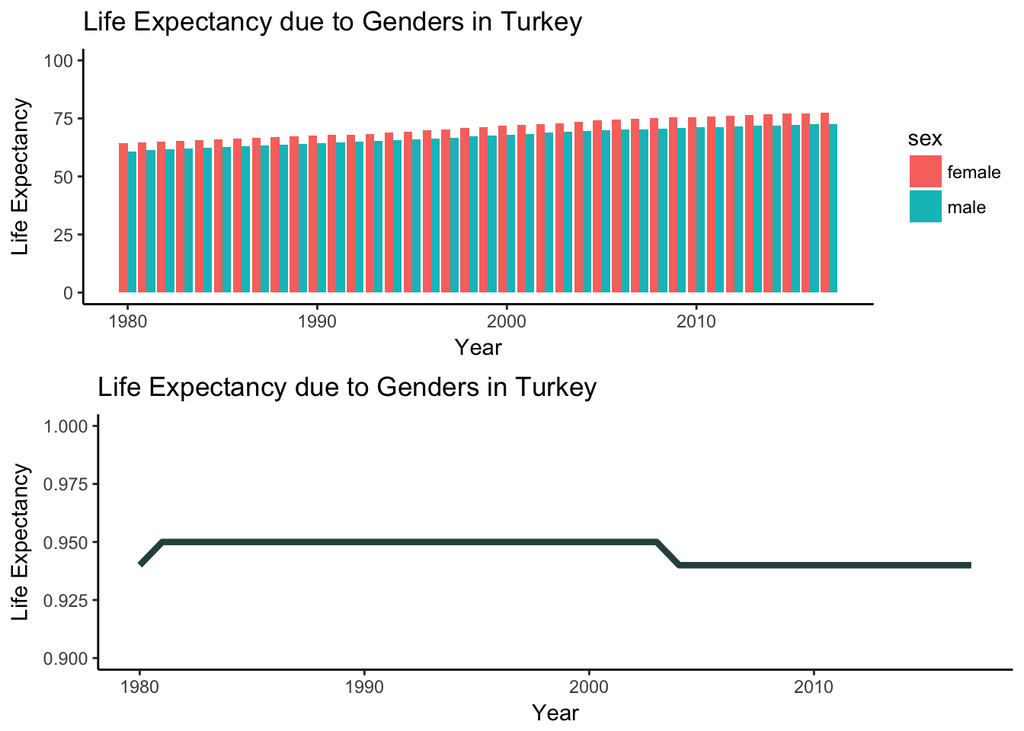

```r
#dim(query.lifeexpectancy)
#summary(query.lifeexpectancy)
#head(query.lifeexpectancy,5)

##1

  g0 <- ggplot(le.tr, aes(x = year, y = life_expectancy, fill = sex)) +
   geom_bar(aes(y=life_expectancy),stat = "identity",position = position_dodge()) +
   scale_y_continuous(limits = c(0,100)) +
   ggtitle("Life Expectancy due to Genders in Turkey") +
   labs(y="Life Expectancy", x="Year") +
   theme_classic()

  g1 <- ggplot(le.tr, aes(x = year, y = male_female_ratio_tr)) +
   geom_line(size=1.5,color=c("darkslategrey")) +
   scale_y_continuous(limits = c(0.90,1)) +
   ggtitle("Life Expectancy due to Genders in Turkey") +
   labs(y="Life Expectancy", x="Year") +
   theme_classic()

  g2 <- ggplot(le.tot, aes(x = year, y = life_expectancy, fill = sex)) +
   geom_bar(aes(y=life_expectancy),stat = "identity",position = position_dodge()) +
   scale_y_continuous(limits = c(0,100)) +
   ggtitle(" AVG Life Expectancy due to Genders in the World") +
   labs(y="Life Expectancy", x="Year") +
   theme_classic()

  g3 <- ggplot(le.tot, aes(x = year, y = male_female_ratio_tot)) +
   geom_line(size=1.5,color=c("darkslategrey")) +
   scale_y_continuous(limits = c(0.90,1)) +
   ggtitle(" AVG Life Expectancy due to Genders in the World") +
   labs(y="Life Expectancy", x="Year") +
   theme_classic()

 grid.arrange(g0,g1,ncol=1)
```

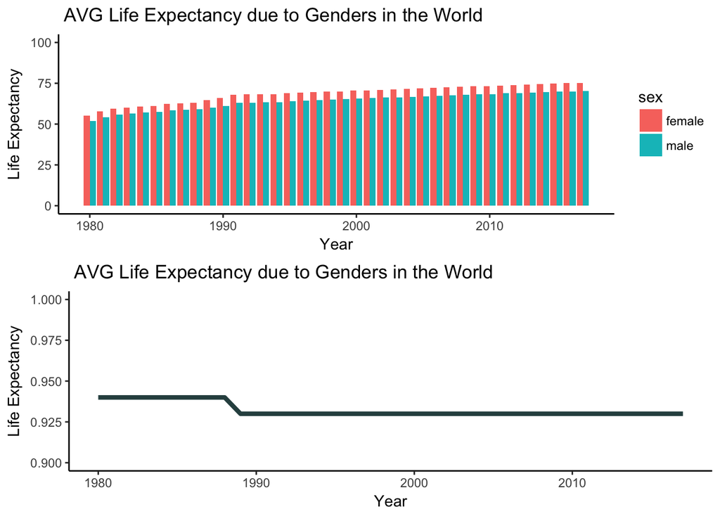

```r
 grid.arrange(g2,g3,ncol=1)
```

- Find the distinct count of country to use on calculations.

```r
query.cnt_country<-dbGetQuery(con,"SELECT
                                      COUNT(DISTINCT(COUNTRY_NAME)) AS NUMBER_OF_COUNTRY
                                      FROM
                                      MORTALITY_LIFE_EXPECTANCY"
                                  )

query.cnt_country
```

```
##   number_of_country
## 1               228
```

- Find the crude birth rate like as follow:

```r
query.crude_birth_rate<-dbGetQuery(con,"SELECT
                                      TR.YEAR,
                                      TR.CRUDE_BIRTH_RATE AS CRUDE_BIRTH_RATE_TR,
                                      TR.CRUDE_DEATH_RATE AS CRUDE_DEATH_RATE_TR,
                                      ROUND(CAST(FLOAT8 (TR.CRUDE_BIRTH_RATE/TR.CRUDE_DEATH_RATE) AS NUMERIC), 2) AS BIRTH_DATE_RATIO_TR,
                                      TOT.CRUDE_BIRTH_RATE AS CRUDE_BIRTH_RATE_TOT,
                                      TOT.CRUDE_DEATH_RATE AS CRUDE_DEATH_RATE_TOT,
                                      ROUND(CAST(FLOAT8 (TOT.CRUDE_BIRTH_RATE/TOT.CRUDE_DEATH_RATE) AS NUMERIC), 2) AS BIRTH_DATE_RATIO_TOT
                                      FROM
                                      (
                                          SELECT
                                          YEAR,
                                          CRUDE_BIRTH_RATE,
                                          CRUDE_DEATH_RATE
                                          FROM
                                          BIRTH_DEATH_GROWTH_RATES
                                          WHERE COUNTRY_NAME = 'Turkey'
                                          AND YEAR <= 2017
                                      ) TR
                                      JOIN
                                      (
                                          SELECT
                                          YEAR,
                                          ROUND(CAST(FLOAT8 (AVG(CRUDE_BIRTH_RATE)) AS NUMERIC), 2) CRUDE_BIRTH_RATE,
                                          ROUND(CAST(FLOAT8 (AVG(CRUDE_DEATH_RATE)) AS NUMERIC), 2) AS CRUDE_DEATH_RATE
                                          FROM
                                          BIRTH_DEATH_GROWTH_RATES
                                          WHERE YEAR <= 2017
                                          GROUP BY YEAR
                                      ) TOT ON TR.YEAR = TOT.YEAR
                                      ORDER BY TR.YEAR"
                                  )

#query.crude_birth_rate
#dim(query.crude_birth_rate)
#summary(query.crude_birth_rate)
head(query.crude_birth_rate,5)
```

```
##   year crude_birth_rate_tr crude_death_rate_tr birth_date_ratio_tr
## 1 1980               35.05                9.40                3.73
## 2 1981               34.75                9.19                3.78
## 3 1982               33.59                8.93                3.76
## 4 1983               32.42                8.65                3.75
## 5 1984               31.22                8.39                3.72
##   crude_birth_rate_tot crude_death_rate_tot birth_date_ratio_tot
## 1                41.56                15.02                 2.77
## 2                39.76                13.66                 2.91
## 3                38.24                12.83                 2.98
## 4                37.67                12.49                 3.02
## 5                37.01                12.21                 3.03
```

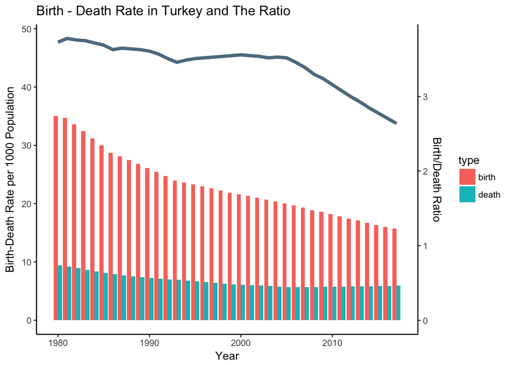

```r
# take birth death rates in Turkey:    --CRUDE_BIRTH_RATE_TR

birth.tr <- query.crude_birth_rate %>%
  select(year,rate=crude_birth_rate_tr,ratio =birth_date_ratio_tr) %>%
  mutate(type="birth")

death.tr <- query.crude_birth_rate %>%
  select(year,rate=crude_death_rate_tr,ratio =birth_date_ratio_tr) %>%
  mutate(type="death")

bd.tr <- union_all(birth.tr,death.tr)

normalizer <- max(bd.tr$rate)/max(bd.tr$ratio)

g0 <- ggplot(bd.tr, aes(x = year, y = rate/normalizer, fill = type)) +
   geom_bar(aes(y=rate),stat = "identity",position = position_dodge()) +
   geom_line(aes(y=ratio*normalizer),size=1.5,color=c("lightskyblue4")) +
   ggtitle("Birth - Death Rate in Turkey and The Ratio") +
   scale_y_continuous(sec.axis = sec_axis(trans = ~.* 1/normalizer, name = 'Birth/Death Ratio'))+
   labs(y="Birth-Death Rate per 1000 Population", x="Year") +
   theme_classic()

# take birth death rates in the World:

birth.tot <- query.crude_birth_rate %>%
  select(year,rate=crude_birth_rate_tot,ratio =birth_date_ratio_tot) %>%
  mutate(type="birth")

death.tot <- query.crude_birth_rate %>%
  select(year,rate=crude_death_rate_tot,ratio =birth_date_ratio_tot) %>%
  mutate(type="death")

bd.tot <- union_all(birth.tot,death.tot)

normalizer <- max(bd.tot$rate)/max(bd.tot$ratio)

g1 <- ggplot(bd.tot, aes(x = year, y = rate/normalizer, fill = type)) +
   geom_bar(aes(y=rate),stat = "identity",position = position_dodge()) +
   geom_line(aes(y=ratio*normalizer),size=1.5,color=c("lightskyblue4")) +
   ggtitle("Birth - Death Rate in the World and The Ratio") +
   scale_y_continuous(sec.axis = sec_axis(trans = ~.* 1/normalizer, name = 'Birth/Death Ratio'))+
   labs(y="Birth-Death Rate per 1000 Population", x="Year") +
   theme_classic()

#grid.arrange(g0,g1,ncol=1)

g0
```

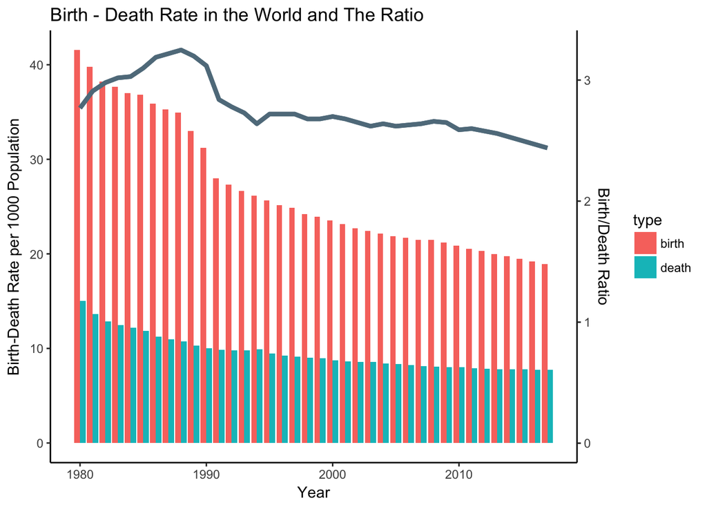

```r
g1
```

- Create a new table with age category:

```r
is_exist <- dbExistsTable(con, "POPULATION_AGE_SUMMARY")
is_exist
```

```
## [1] FALSE
```

```r
dbGetQuery(con,"CREATE TABLE POPULATION_AGE_SUMMARY AS
SELECT
YEAR,
COUNTRY_CODE,
AGE,
CASE
WHEN AGE <= 20 THEN '00 - 20'
WHEN AGE <= 40 THEN '21 - 40'
WHEN AGE <= 60 THEN '41 - 60'
WHEN AGE <= 80 THEN '61 - 80'
WHEN AGE <= 100 THEN '81 - 100' END AGE_CATEGORY,
POPULATION,
SEX
FROM
MIDYEAR_POPULATION_AGE_COUNTRY_CODE
WHERE YEAR <= 2017
ORDER BY AGE"
)
```

- Female Male Population Average for each year both for Turkey and all World.

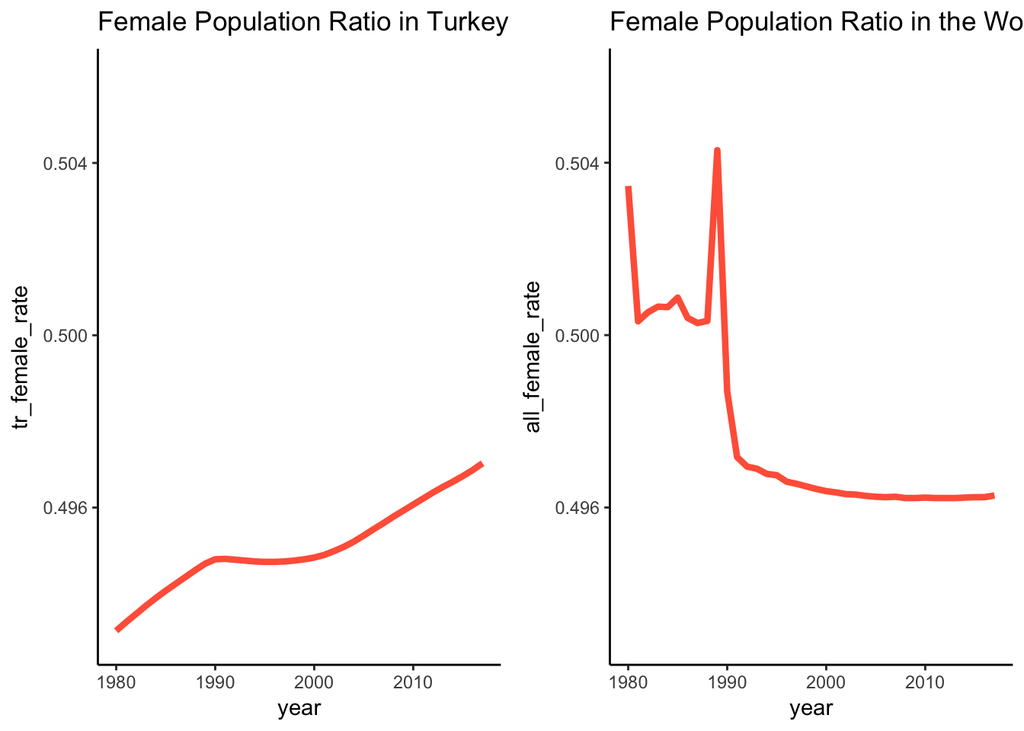

```r
query.sex_aveg_population <-dbGetQuery(con,"WITH TR AS
                (
                   SELECT
                   YEAR,
                   SUM(POPULATION) AS POPULATION_TOT_TR,
                   SUM(CASE WHEN SEX = 'Male' THEN POPULATION END) AS POPULATION_MALE_TR,
                   SUM(CASE WHEN SEX = 'Female' THEN POPULATION END) AS POPULATION_FEMALE_TR
                   FROM
                   POPULATION_AGE_SUMMARY
                   WHERE COUNTRY_CODE = 'TU'
                   GROUP BY YEAR
                ),
                ALLS AS
                (
                   SELECT
                   YEAR,
                   SUM(POPULATION)/COUNT(DISTINCT COUNTRY_CODE) AS POPULATION_TOT_ALL,
                   SUM(CASE WHEN SEX = 'Male' THEN POPULATION END)/COUNT(DISTINCT COUNTRY_CODE) AS POPULATION_MALE_ALL,
                   SUM(CASE WHEN SEX = 'Female' THEN POPULATION END)/COUNT(DISTINCT COUNTRY_CODE) AS POPULATION_FEMALE_ALL
                   FROM
                   POPULATION_AGE_SUMMARY
                   GROUP BY YEAR
                )
                SELECT
                TR.YEAR,
                POPULATION_TOT_TR,
                POPULATION_MALE_TR,
                POPULATION_FEMALE_TR,
                POPULATION_TOT_ALL,
                POPULATION_MALE_ALL,
                POPULATION_FEMALE_ALL
                FROM TR
                JOIN ALLS ON TR.YEAR = ALLS.YEAR
                ORDER BY TR.YEAR DESC")

new <- query.sex_aveg_population%>% mutate(tr_male_rate = round(population_male_tr/population_tot_tr,5),
                                          tr_female_rate =round(population_female_tr/population_tot_tr,5),
                                          all_male_rate = round(population_male_all/population_tot_all,5),
                                          all_female_rate = round(population_female_all/population_tot_all,5))
#head(new,38)


g0 <- ggplot(new,aes(x=year,y=tr_female_rate)) + geom_line(size=1.5,color=c("tomato")) +
      scale_y_continuous(limits=c(0.493,0.506)) +
      ggtitle("Female Population Ratio in Turkey") + theme_classic()
g1 <- ggplot(new,aes(x=year,y=all_female_rate)) + geom_line(size=1.5,color=c("tomato")) +
      scale_y_continuous(limits=c(0.493,0.506)) +
      ggtitle("Female Population Ratio in the World") + theme_classic()

grid.arrange(g0,g1,nrow=1)
```

```r
#query.sex_aveg_population
#head(query.sex_aveg_population)
#dim(query.sex_aveg_population)
#summary(query.sex_aveg_population)
#head(query.sex_aveg_population,38)
```

- Population distribution and rates among the age categories:

```r
query.avg_population <-dbGetQuery(con,"WITH TR AS
                          (
                            SELECT
                            YEAR,
                            SUM(CASE WHEN AGE_CATEGORY = '00 - 20' THEN POPULATION ELSE 0 END) AS TR_00_20_POPULATION,
                            SUM(CASE WHEN AGE_CATEGORY = '21 - 40' THEN POPULATION ELSE 0 END) AS TR_21_40_POPULATION,
                            SUM(CASE WHEN AGE_CATEGORY = '41 - 60' THEN POPULATION ELSE 0 END) AS TR_41_60_POPULATION,
                            SUM(CASE WHEN AGE_CATEGORY = '61 - 80' THEN POPULATION ELSE 0 END) AS TR_61_80_POPULATION,
                            SUM(CASE WHEN AGE_CATEGORY = '81 - 100' THEN POPULATION ELSE 0 END) AS TR_81_100_POPULATION,
                            SUM(POPULATION) AS POPULATION_TR
                            FROM
                            POPULATION_AGE_SUMMARY
                            WHERE COUNTRY_CODE = 'TU'
                            GROUP BY YEAR
                          ),
                          ALLS AS
                          (
                            SELECT
                            YEAR,
                            SUM(CASE WHEN AGE_CATEGORY = '00 - 20' THEN POPULATION ELSE 0 END)/COUNT(DISTINCT COUNTRY_CODE) AS ALL_00_20_POPULATION,
                            SUM(CASE WHEN AGE_CATEGORY = '21 - 40' THEN POPULATION ELSE 0 END)/COUNT(DISTINCT COUNTRY_CODE) AS ALL_21_40_POPULATION,
                            SUM(CASE WHEN AGE_CATEGORY = '41 - 60' THEN POPULATION ELSE 0 END)/COUNT(DISTINCT COUNTRY_CODE) AS ALL_41_60_POPULATION,
                            SUM(CASE WHEN AGE_CATEGORY = '61 - 80' THEN POPULATION ELSE 0 END)/COUNT(DISTINCT COUNTRY_CODE) AS ALL_61_80_POPULATION,
                            SUM(CASE WHEN AGE_CATEGORY = '81 - 100' THEN POPULATION ELSE 0 END)/COUNT(DISTINCT COUNTRY_CODE) AS ALL_81_100_POPULATION,
                            SUM(POPULATION)/COUNT(DISTINCT COUNTRY_CODE) AS POPULATION_ALL   FROM
                            POPULATION_AGE_SUMMARY
                            GROUP BY YEAR
                          )
                          SELECT
                          TR.YEAR,
                          TR_00_20_POPULATION,
                          TR_21_40_POPULATION,
                          TR_41_60_POPULATION,
                          TR_61_80_POPULATION,
                          TR_81_100_POPULATION,
                          POPULATION_TR,
                          ALL_00_20_POPULATION,
                          ALL_21_40_POPULATION,
                          ALL_41_60_POPULATION,
                          ALL_61_80_POPULATION,
                          ALL_81_100_POPULATION,
                          POPULATION_ALL FROM TR
                          JOIN ALLS ON TR.YEAR = ALLS.YEAR
                          ORDER BY TR.YEAR DESC")



new <- query.avg_population %>% mutate(tr_0_20_rate = round(tr_00_20_population /population_tr,3),
                                       all_0_20_rate = round(all_00_20_population /population_all,3))
head(new)
```

```
##   year tr_00_20_population tr_21_40_population tr_41_60_population
## 1 2017            27854340            25727823            18752948
## 2 2016            28032636            25716505            18327377
## 3 2015            28060856            25610177            17861529
## 4 2014            28001071            25453179            17377113
## 5 2013            27937543            25279204            16897511
## 6 2012            27884901            25076461            16424354
##   tr_61_80_population tr_81_100_population population_tr
## 1             7567590               942514      80845215
## 2             7294927               903159      80274604
## 3             7021889               859818      79414269
## 4             6757467               813137      78401967
## 5             6510226               764157      77388641
## 6             6282621               713420      76381757
##   all_00_20_population all_21_40_population all_41_60_population
```

[output cut: 20 more lines]

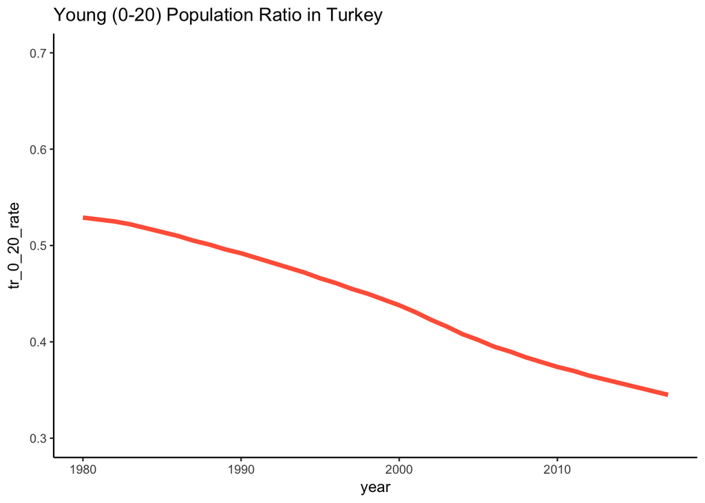

```r
g0 <- ggplot(new,aes(x=year,y=tr_0_20_rate)) + geom_line(size=1.5,color=c("tomato")) +
      scale_y_continuous(limits=c(0.30,0.70)) +
      ggtitle("Young (0-20) Population Ratio in Turkey") + theme_classic()
g1 <- ggplot(new,aes(x=year,y=all_0_20_rate)) + geom_line(size=1.5,color=c("tomato")) +
      scale_y_continuous(limits=c(0.30,0.70)) +
      ggtitle("Young(0-20) Population Ratio in the World") + theme_classic()

g0
```

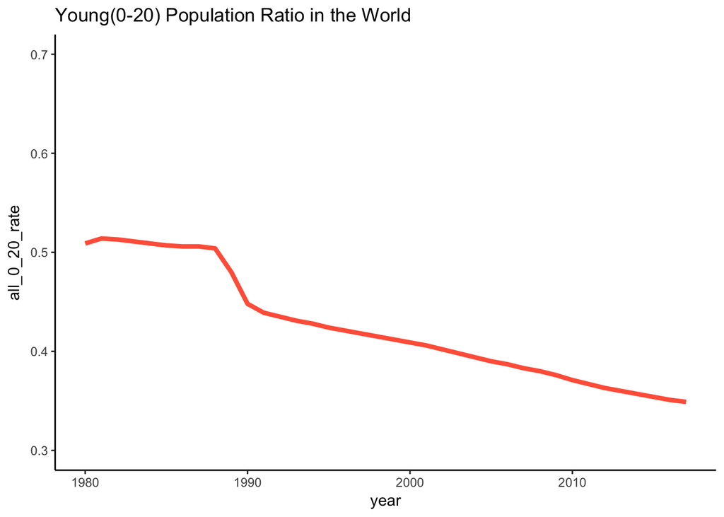

```r
g1
```

```r
#query.sex_aveg_population
#head(query.avg_population)
#dim(query.avg_population )
#summary(query.avg_population)
#head(query.sex_aveg_population,38)
```

- Young population among the selected years in the World:

```r
query.young_population<-dbGetQuery(con,"SELECT
                                      YEAR,
                                      COUNTRY_CODE,
                                      SUM(CASE WHEN AGE_CATEGORY = '00 - 20' THEN POPULATION ELSE 0 END) AS _00_20_POPULATION,
                                      SUM(POPULATION) AS POPULATION,
                                      SUM(CASE WHEN AGE_CATEGORY = '00 - 20' THEN POPULATION ELSE 0 END)/SUM(POPULATION) AS YOUNG_RATIO
                                      FROM
                                      POPULATION_AGE_SUMMARY
                                      WHERE YEAR IN (1980,2000,2017)
                                      GROUP BY YEAR,COUNTRY_CODE
                                      ORDER BY 1 ,5 DESC")



dim(query.young_population)
```

```
## [1] 525   5
```

```r
summary(query.young_population)
```

```
##       year      country_code       _00_20_population     population
##  Min.   :1980   Length:525         Min.   :     1170   Min.   :3.951e+03
##  1st Qu.:2000   Class :character   1st Qu.:   213404   1st Qu.:5.451e+05
##  Median :2000   Mode  :character   Median :  1767869   Median :4.955e+06
##  Mean   :2005                      Mean   : 10749301   Mean   :2.782e+07
##  3rd Qu.:2017                      3rd Qu.:  7520956   3rd Qu.:1.708e+07
##  Max.   :2017                      Max.   :490228691   Max.   :1.379e+09
##   young_ratio
##  Min.   :0.1618
##  1st Qu.:0.2927
##  Median :0.4246
##  Mean   :0.4147
##  3rd Qu.:0.5447
##  Max.   :0.6360
```

```r
head(query.young_population,38)
```

```
##    year country_code _00_20_population population young_ratio
## 1  1980           KE          10283956   16330697   0.6297316
## 2  1980           UG           7513521   12019708   0.6251001
## 3  1980           CV            183542     296446   0.6191414
## 4  1980           ZA           3429060    5540358   0.6189239
## 5  1980           HO           2090795    3402468   0.6144937
## 6  1980           NU           1702952    2803030   0.6075397
## 7  1980           BP            140070     230768   0.6069732
## 8  1980           BH             87102     144416   0.6031326
## 9  1980           WZ            368352     611463   0.6024109
## 10 1980           BN           2076072    3458062   0.6003571
## 11 1980           RW           3068520    5139838   0.5970071
## 12 1980           UV           3755120    6318189   0.5943349
## 13 1980           SO           3438444    5793555   0.5934947
## 14 1980           CN            201355     339757   0.5926442
```

[output cut: 24 more lines]